# Practical 4: Linear models

Author

Benjamin Rosenbaum

We learn about linear models with continuous or categorical predictors, namely linear regression, ANOVA, ANCOVA

Research questions are answered via model selection (LOO), but also with comparison of posterior predictions (counterfactuals, “what-if” scenarios). With categorical predictors, the emmeans package is helpful here.

```r
rm(list=ls())
library("brms")
library("bayesplot")
library("performance")
library("ggplot2")
library("emmeans")
library("ecostats")
library("Data4Ecologists")
library("cowplot")
try(dev.off())
```

# Regression, additive

We use the same global plants dataset as before (from the ecostats package). We use an additional predictor rainfall and we scale both predictors (`scale()`, mean=0, sd=1). This makes things easier especially when involving interactions.

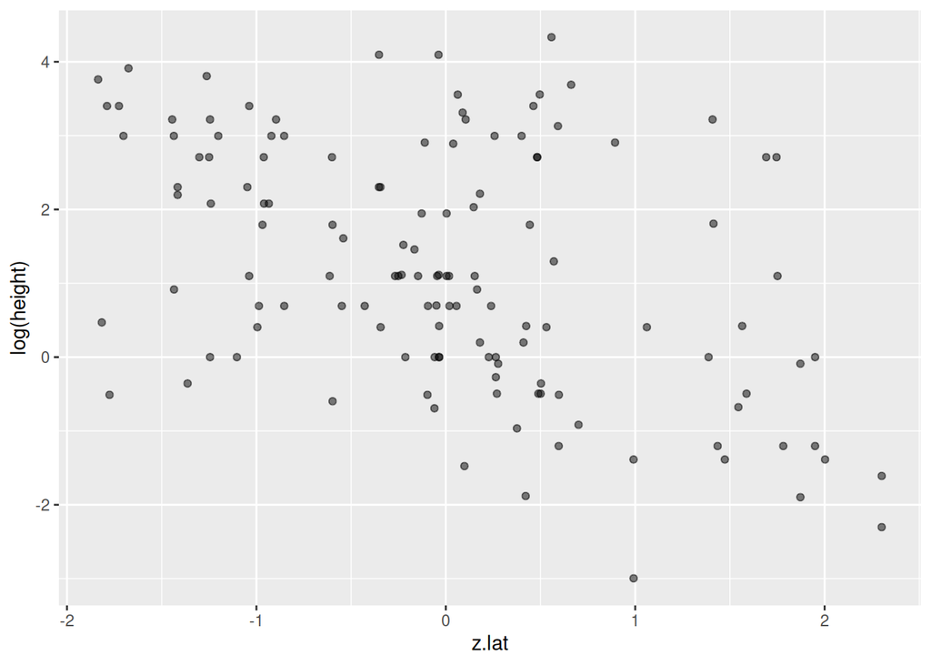

```r
data(globalPlants)
globalPlants$z.lat = scale(globalPlants$lat)
globalPlants$z.rain = scale(globalPlants$rain)
ggplot(globalPlants, aes(z.lat, log(height))) + geom_point(alpha=0.5)
```

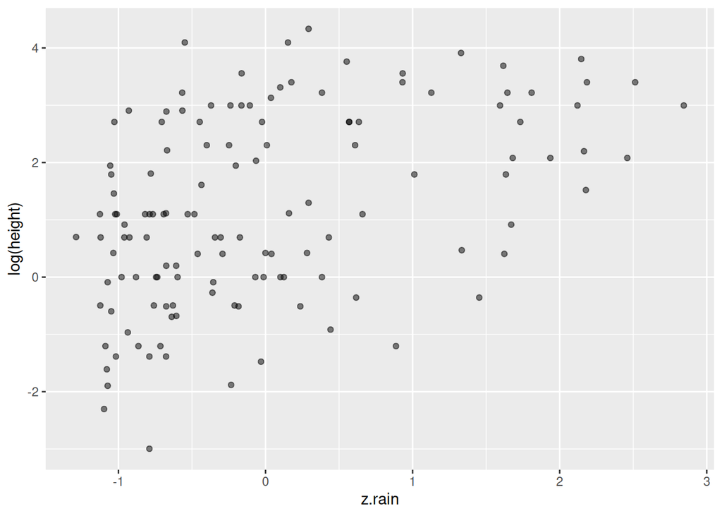

```r
ggplot(globalPlants, aes(z.rain, log(height))) + geom_point(alpha=0.5)
```

Here, we want to examine the latitudinal gradient in plant height, while controlling for rainfall.

Deterministic part: $\mu=b_0+b_1\cdot lat+b_2\cdot rain$  
Stochastic part: $\log(height) \sim \text{Normal}(\mu,\sigma)$

We use vaguely informative priors, we expect a negative relation with latitude, a positive one with rainfall.

```r
fit.lm.add = brm(log(height) ~ z.lat + z.rain,
                 prior =
                   prior(normal(-1,1), class=b, coef=z.lat) +
                   prior(normal(+1,1), class=b, coef=z.rain),
                 data = globalPlants)
```

We check for convergence as usual, everything OK here.

```r
summary(fit.lm.add, prior=TRUE)
```

```
 Family: gaussian
  Links: mu = identity; sigma = identity
Formula: log(height) ~ z.lat + z.rain
   Data: globalPlants (Number of observations: 131)
  Draws: 4 chains, each with iter = 2000; warmup = 1000; thin = 1;
         total post-warmup draws = 4000

Priors:
b_z.lat ~ normal(-1, 1)
b_z.rain ~ normal(+1, 1)
Intercept ~ student_t(3, 1.1, 2.5)
<lower=0> sigma ~ student_t(3, 0, 2.5)

Regression Coefficients:
          Estimate Est.Error l-95% CI u-95% CI Rhat Bulk_ESS Tail_ESS
Intercept     1.19      0.12     0.95     1.43 1.00     3766     2606
z.lat        -0.48      0.15    -0.79    -0.18 1.00     3259     2543
z.rain        0.47      0.16     0.16     0.77 1.00     3431     2928

Further Distributional Parameters:
      Estimate Est.Error l-95% CI u-95% CI Rhat Bulk_ESS Tail_ESS
sigma     1.45      0.09     1.29     1.64 1.00     3632     2694

Draws were sampled using sampling(NUTS). For each parameter, Bulk_ESS
and Tail_ESS are effective sample size measures, and Rhat is the potential
scale reduction factor on split chains (at convergence, Rhat = 1).
```

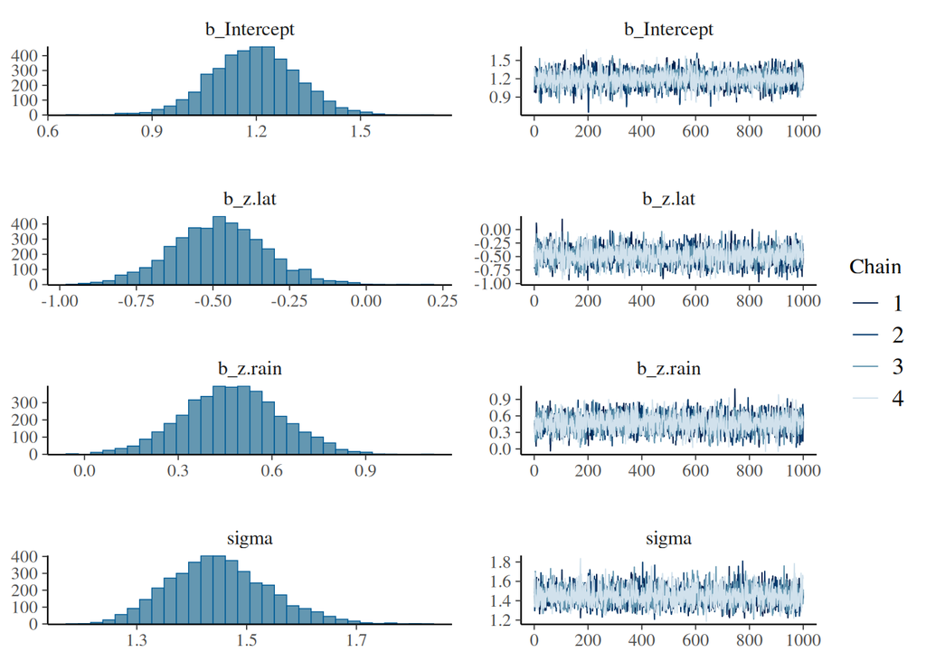

```r
plot(fit.lm.add)
```

Now we check predictions, to evaluate if the model fits the data well.

`conditional_effects()` will plot predictions against each predictor, while the other one is held constant at its mean (here =0 because we scaled it).

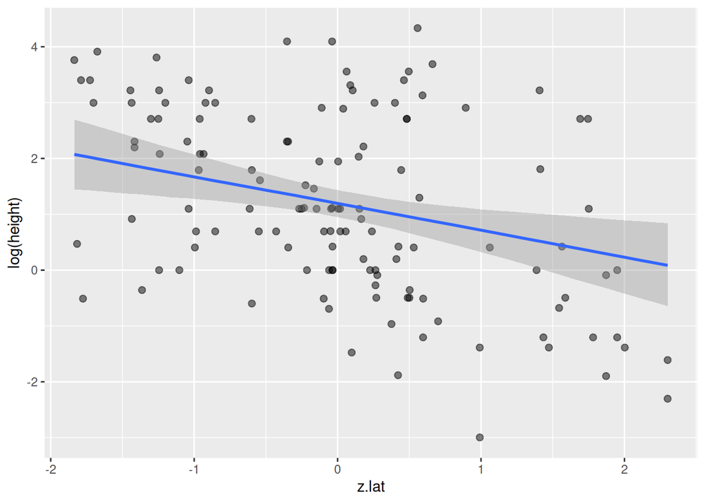

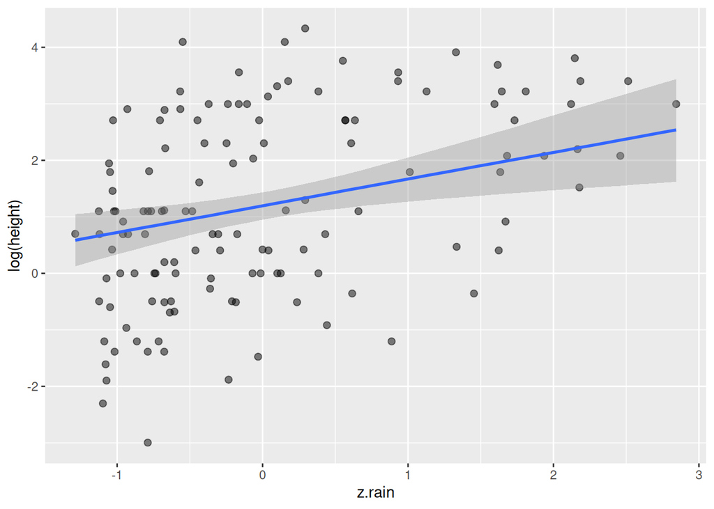

```r
plot(conditional_effects(fit.lm.add),
     points=TRUE,
     point_args=c(alpha=0.5),
     ask=FALSE)
```

You can also specify the predictor with `effects=""`, if you want to plot them separately.

```r
plot(conditional_effects(fit.lm.add, effects="z.lat"),
     points=TRUE,
     point_args=c(alpha=0.5))
plot(conditional_effects(fit.lm.add, effects="z.rain"),
     points=TRUE,
     point_args=c(alpha=0.5))
```

Although the model does not contain an interaction, `"z.lat:z.rain"` will plot fitted effects of `z.lat` for 3 levels of `z.rain` (mean-1sd, mean, mean+1sd). `prob=...` chooses the quantiles of model uncertainty. With `prob=0` we do not plot any uncertainty and just the mean regression line for better visibility.

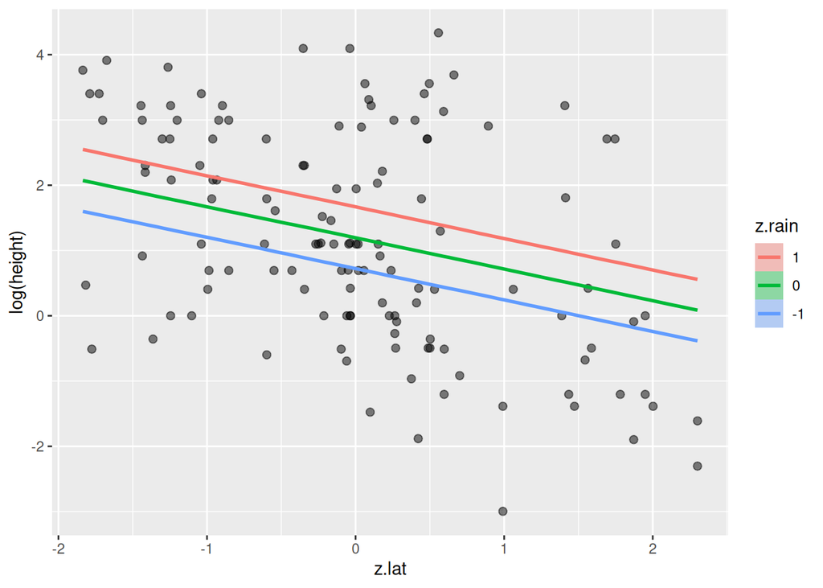

```r
plot(conditional_effects(fit.lm.add, effects="z.lat:z.rain", prob=0),
     points=TRUE,
     point_args=c(alpha=0.5))
```

Note that lines are always parallel in an additive model.

We an also plot the effects of the 2nd predictor `z.rain` for 3 levels of `z.lat` by switching the order `"z.rain:z.lat"`.

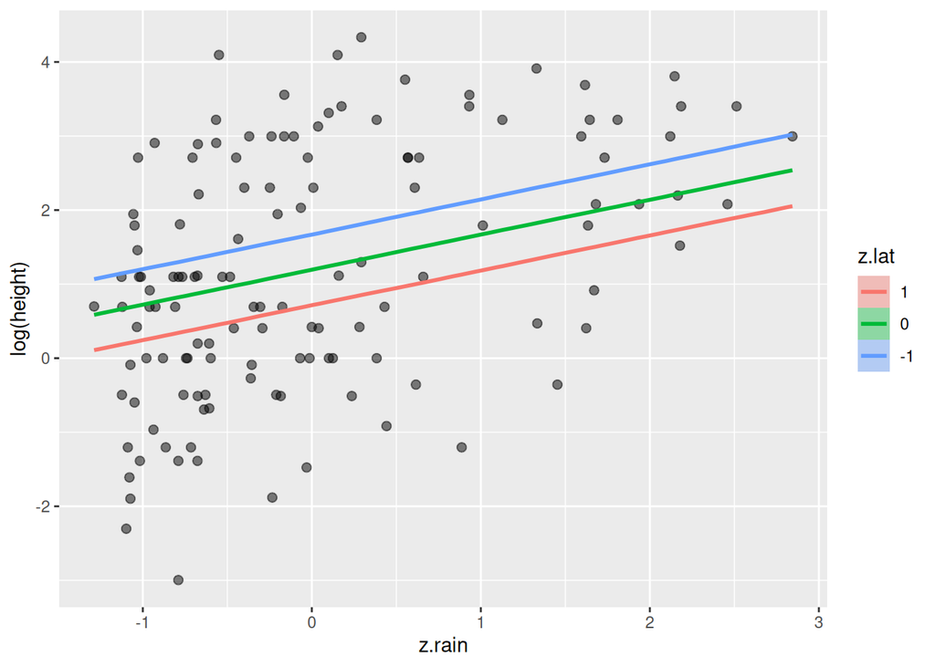

```r
plot(conditional_effects(fit.lm.add, effects="z.rain:z.lat", prob=0),
     points=TRUE,
     point_args=c(alpha=0.5))
```

With more than one predictor, it’s getting more difficult to assess the quality of model fit from these plots.

Posterior predictive plots, on the other hand, are independent from the number of predictor variables.

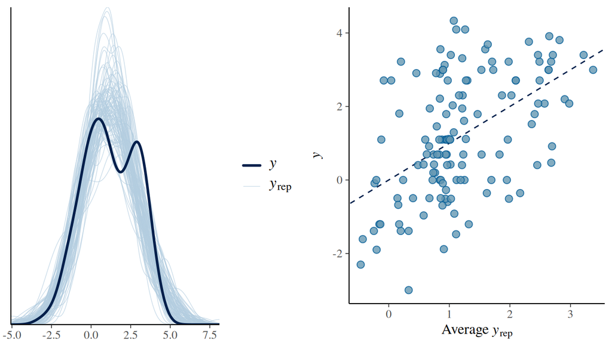

```r
p1 = pp_check(fit.lm.add, ndraws=100)
p2 = pp_check(fit.lm.add, type="scatter_avg")
plot_grid(p1,p2)
```

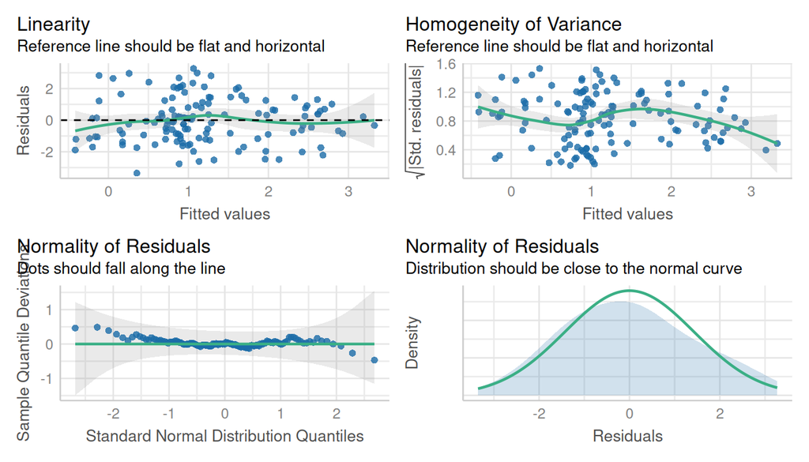

```r
check_model(fit.lm.add, check=c("linearity","homogeneity","qq","normality"))
```

There is still a lot of unexplained variation, but at least linear model assumptions seem to be satisfied.

```r
bayes_R2(fit.lm.add)
```

```
    Estimate  Est.Error      Q2.5     Q97.5
R2 0.2603617 0.05539821 0.1479813 0.3644788
```

**Question:** Is the average plant height at mean latitude and mean rainfall different from a tropical scenario (close to equator, high rainfall).

We can make **counterfactual predictions** for these 2 scenarios to answer this question.

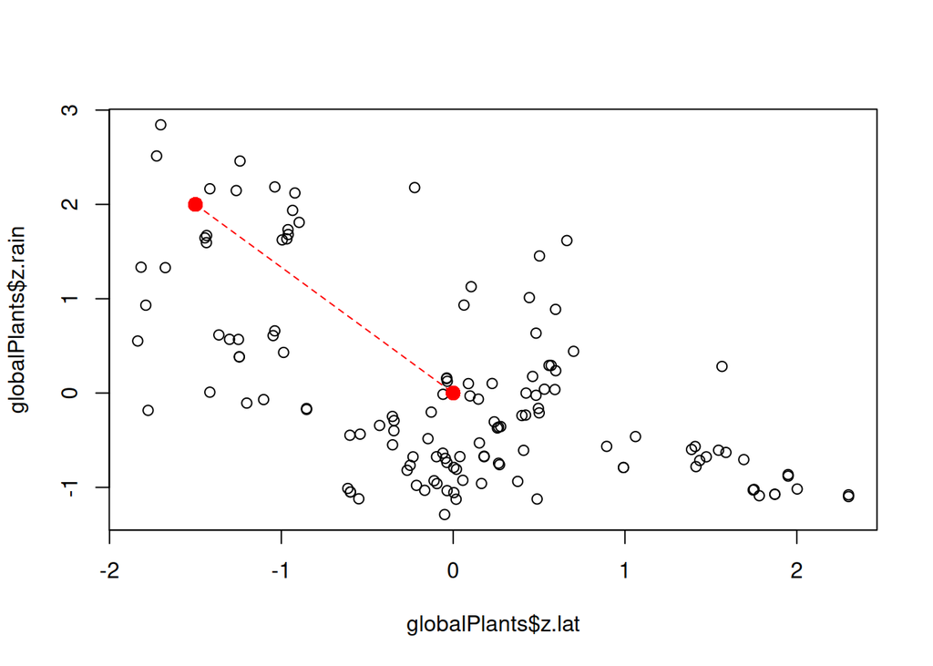

```r
plot(globalPlants$z.lat, globalPlants$z.rain)
points(0,0,col="red", pch=16, cex=1.5)
points(-1.5,2,col="red", pch=16, cex=1.5)
lines(c(-1.5,0),c(2,0), col="red", lty=2)
```

Computing predictions is not enough to make a quantitative statement on the question.

```r
fitted(fit.lm.add, newdata=data.frame(z.lat=-1.5, z.rain=2))
```

```
     Estimate Est.Error     Q2.5    Q97.5
[1,] 2.856993 0.2908321 2.286048 3.413919
```

```r
fitted(fit.lm.add, newdata=data.frame(z.lat= 0,   z.rain=0))
```

```
     Estimate Est.Error      Q2.5   Q97.5
[1,]  1.19341 0.1235972 0.9500366 1.43438
```

We need to extract full posterior predictive distributions and compute the distribution of predicted difference. Then we can look at mean difference and credible intervals

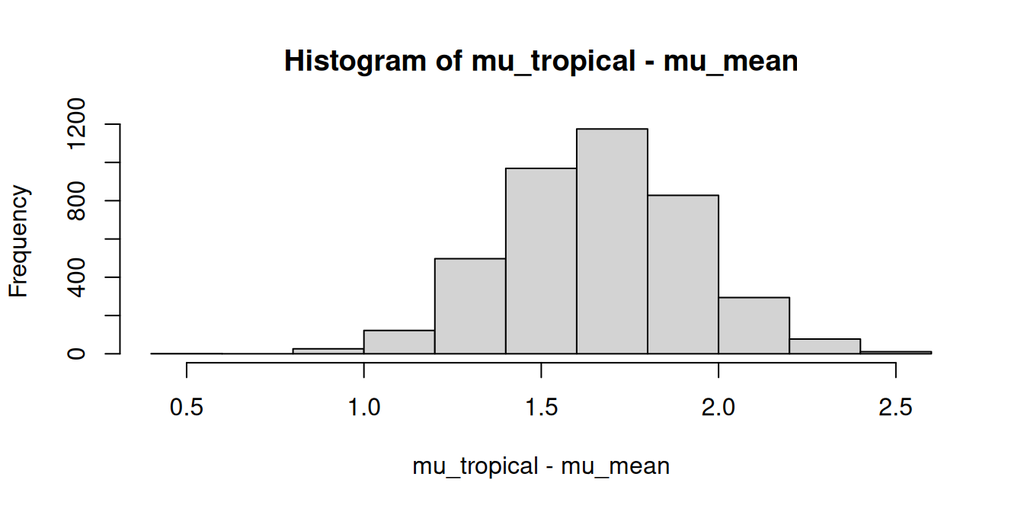

```r
mu_tropical = posterior_epred(fit.lm.add, newdata=data.frame(z.lat=-1.5, z.rain=2))
mu_mean     = posterior_epred(fit.lm.add, newdata=data.frame(z.lat= 0,   z.rain=0))
hist(mu_tropical-mu_mean)
```

```r
mean(mu_tropical-mu_mean)
```

```
[1] 1.663584
```

```r
quantile(mu_tropical-mu_mean, probs=c(0.05, 0.95))
```

```
      5%      95%
1.235225 2.088131
```

Alternatively, we can use the `hypothesis()` function and get the same results

```r
mus = fitted(fit.lm.add,
             newdata=data.frame(z.lat =c(-1.5,0),
                                z.rain=c( 2  ,0)),
             summary=F)
mus = as.data.frame(mus)
names(mus) = c("tropical","mean")
hypothesis(mus, "tropical>mean")
```

```
Hypothesis Tests for class :
             Hypothesis Estimate Est.Error CI.Lower CI.Upper Evid.Ratio Post.Prob Star
1 (tropical)-(mean) > 0     1.66      0.26     1.24     2.09        Inf         1    *
---
'CI': 90%-CI for one-sided and 95%-CI for two-sided hypotheses.
'*': For one-sided hypotheses, the posterior probability exceeds 95%;
for two-sided hypotheses, the value tested against lies outside the 95%-CI.
Posterior probabilities of point hypotheses assume equal prior probabilities.
```

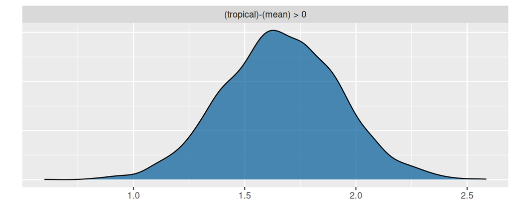

```r
hypothesis(mus, "tropical>mean") |> plot()
```

# Regression, interaction

**Question:** Does effect of rain change with latitude?  
–> need an interaction model

Deterministic part: $\mu=b_0+b_1\cdot lat+b_2\cdot rain+b_3\cdot lat\cdot rain$  
Stochastic part: $\log(height) \sim \text{Normal}(\mu,\sigma)$

We use the same priors as before for 2 main effects (slopes when other predictor is =0, here =mean). Vague prior is put on interaction, with zero mean.

**Mean-centering makes main effects $b_1,b_2$ meaningful and prior choice simpler!**

```r
fit.lm.int = brm(log(height) ~ z.lat * z.rain,
                 prior =
                   prior(normal(-1,1), class=b, coef=z.lat) +
                   prior(normal(+1,1), class=b, coef=z.rain) +
                   prior(normal( 0,1), class=b, coef=z.lat:z.rain),
                 data = globalPlants)
```

Convergence checks looking good!

```r
summary(fit.lm.int, prior=TRUE)
```

```
 Family: gaussian
  Links: mu = identity; sigma = identity
Formula: log(height) ~ z.lat * z.rain
   Data: globalPlants (Number of observations: 131)
  Draws: 4 chains, each with iter = 2000; warmup = 1000; thin = 1;
         total post-warmup draws = 4000

Priors:
b_z.lat ~ normal(-1, 1)
b_z.lat:z.rain ~ normal(0, 1)
b_z.rain ~ normal(+1, 1)
Intercept ~ student_t(3, 1.1, 2.5)
<lower=0> sigma ~ student_t(3, 0, 2.5)

Regression Coefficients:
             Estimate Est.Error l-95% CI u-95% CI Rhat Bulk_ESS Tail_ESS
Intercept        1.30      0.15     1.00     1.60 1.00     4041     2882
z.lat           -0.44      0.15    -0.74    -0.14 1.00     3475     3299
z.rain           0.58      0.17     0.25     0.92 1.00     3220     3186
z.lat:z.rain     0.19      0.14    -0.08     0.46 1.00     3317     3186

Further Distributional Parameters:
      Estimate Est.Error l-95% CI u-95% CI Rhat Bulk_ESS Tail_ESS
sigma     1.45      0.09     1.28     1.64 1.00     4272     2845

Draws were sampled using sampling(NUTS). For each parameter, Bulk_ESS
and Tail_ESS are effective sample size measures, and Rhat is the potential
scale reduction factor on split chains (at convergence, Rhat = 1).
```

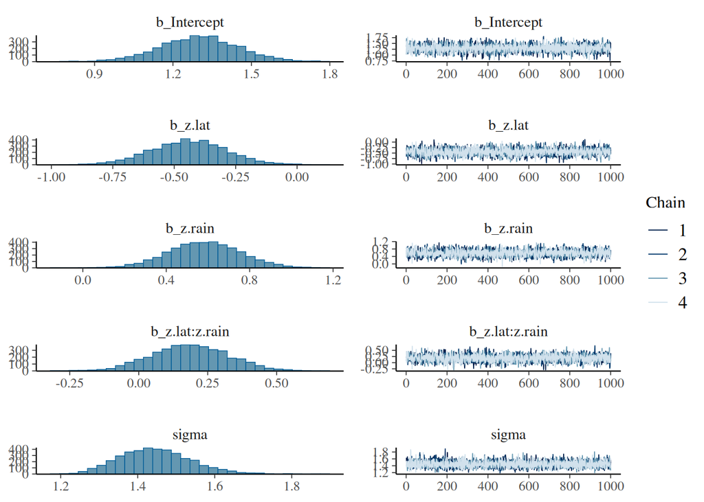

```r
plot(fit.lm.int)
```

Now `conditional_effects` shows interaction for 3 levels of 2nd predictor

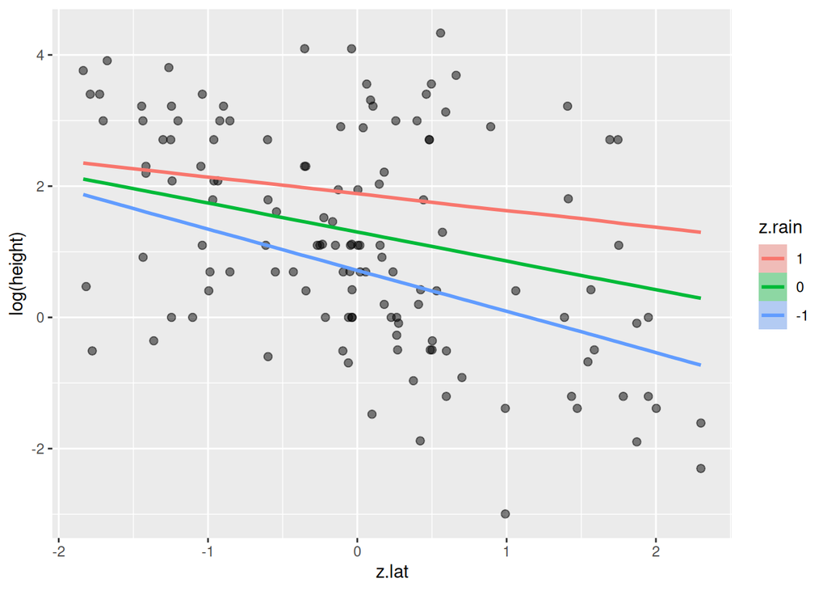

```r
plot(conditional_effects(fit.lm.int, effects="z.lat:z.rain", prob=0),
     points=TRUE,
     point_args=c(alpha=0.5))
```

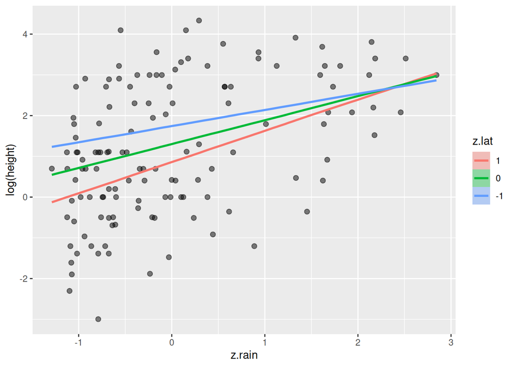

```r
plot(conditional_effects(fit.lm.int, effects="z.rain:z.lat", prob=0),
     points=TRUE,
     point_args=c(alpha=0.5))
```

We see some interaction, the effect of rain (slope) becomes stronger (more important) with latitude.

We quickly do some posterior predictive checks before we move on to the quantification of the research question. PPC look okay-ish, but there is some feature in the data (bimodal histogram) that predictions don’t reproduce. This could indicate missing predictors, but we’ll leave it here.

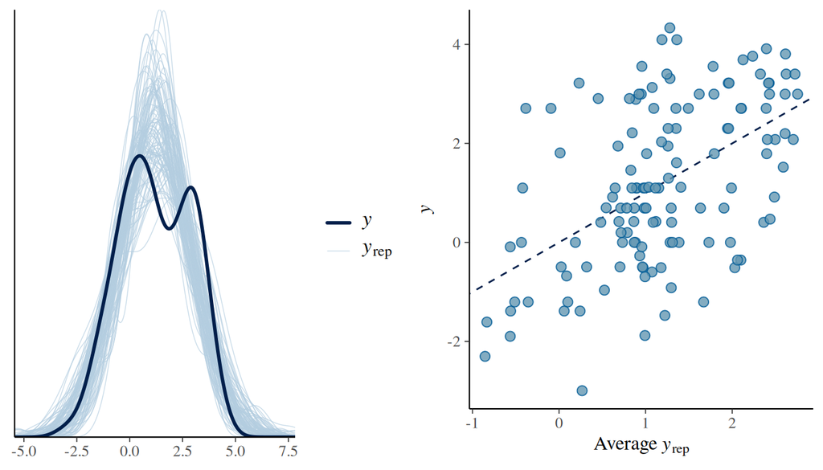

```r
p1 = pp_check(fit.lm.int, ndraws=100)
p2 = pp_check(fit.lm.int, type="scatter_avg")
plot_grid(p1,p2)
```

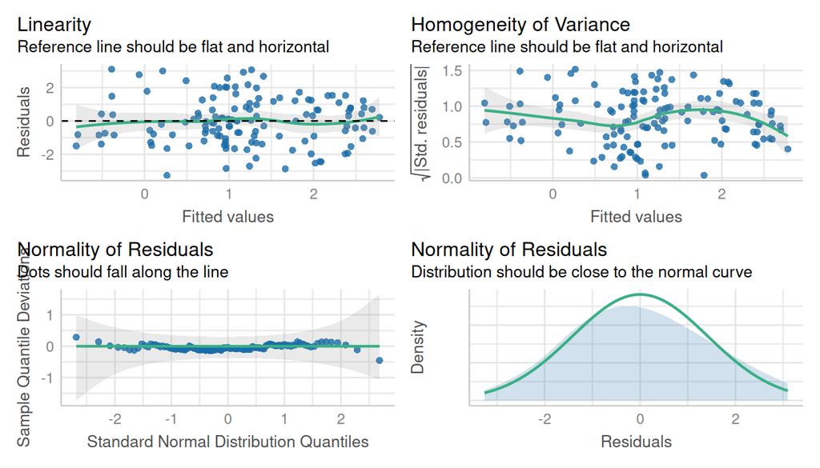

```r
check_model(fit.lm.int, check=c("linearity","homogeneity","qq","normality"))
```

Is the interaction meaningful?

```r
hypothesis(fit.lm.int, "z.lat:z.rain>0")
```

```
Hypothesis Tests for class b:
          Hypothesis Estimate Est.Error CI.Lower CI.Upper Evid.Ratio Post.Prob Star
1 (z.lat:z.rain) > 0     0.19      0.14    -0.04     0.42       9.78      0.91
---
'CI': 90%-CI for one-sided and 95%-CI for two-sided hypotheses.
'*': For one-sided hypotheses, the posterior probability exceeds 95%;
for two-sided hypotheses, the value tested against lies outside the 95%-CI.
Posterior probabilities of point hypotheses assume equal prior probabilities.
```

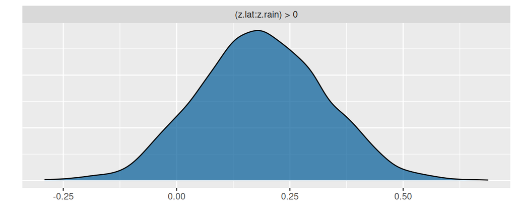

```r
hypothesis(fit.lm.int, "z.lat:z.rain>0") |> plot()
```

We see some (weak) evidence for a positive interaction ($b=0.19$, $P(b>0)=0.91$)

```r
LOO(fit.lm.int, fit.lm.add)
```

```
           elpd_diff se_diff
fit.lm.add  0.0       0.0
fit.lm.int -0.2       1.4
```

But no, we can’t say that the interaction model produces better predictions than the additive model. Data does not sufficiently support hypothesis on an interaction.

# One categorical predictor

New dataset, bird species richness in different landscapes from Data4Ecologists package

**Question:** Does species richness change with landscape type? (1-way ANOVA)

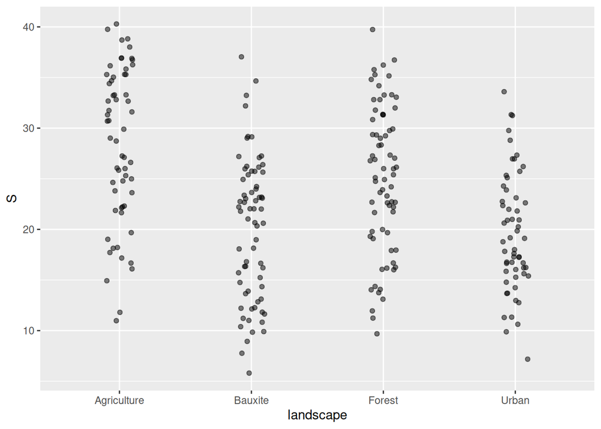

```r
data(birds)
ggplot(birds, aes(x=landscape, y=S)) +
  geom_jitter(width=0.1, alpha=0.5)
```

We can either dummy-code (default) or effect-code the model (`~0+...` removes “intercept”). Which priors does brms use for a categorical predictor?

```r
default_prior(S ~ landscape, data = birds)
```

```
                 prior     class             coef group resp dpar nlpar lb ub       source
                (flat)         b                                                   default
                (flat)         b landscapeBauxite                             (vectorized)
                (flat)         b  landscapeForest                             (vectorized)
                (flat)         b   landscapeUrban                             (vectorized)
 student_t(3, 23, 8.9) Intercept                                                   default
  student_t(3, 0, 8.9)     sigma                                         0         default
```

```r
default_prior(S ~ 0+landscape, data = birds)
```

```
                prior class                 coef group resp dpar nlpar lb ub       source
               (flat)     b                                                       default
               (flat)     b landscapeAgriculture                             (vectorized)
               (flat)     b     landscapeBauxite                             (vectorized)
               (flat)     b      landscapeForest                             (vectorized)
               (flat)     b       landscapeUrban                             (vectorized)
 student_t(3, 0, 8.9) sigma                                             0         default
```

For dummy-coding, a prior for intercept (reference level) is given, but not on effects (differences to reference level).

For effect-coding, no priors are given at all on the group-level means.

–> Either way, we should assign meaningful priors.

```r
fit.anova1.dummy = brm(S ~ landscape,
                       prior = prior(normal(0,10), class=b), # on differences
                       data = birds)
fit.anova1.effect = brm(S ~ 0+landscape,
                        prior = prior(normal(20,10), class=b), # on actual means
                        data = birds)
```

```r
summary(fit.anova1.dummy, prior=TRUE)
```

```
 Family: gaussian
  Links: mu = identity; sigma = identity
Formula: S ~ landscape
   Data: birds (Number of observations: 257)
  Draws: 4 chains, each with iter = 2000; warmup = 1000; thin = 1;
         total post-warmup draws = 4000

Priors:
b ~ normal(0, 10)
Intercept ~ student_t(3, 23, 8.9)
<lower=0> sigma ~ student_t(3, 0, 8.9)

Regression Coefficients:
                 Estimate Est.Error l-95% CI u-95% CI Rhat Bulk_ESS Tail_ESS
Intercept           28.24      0.91    26.43    30.04 1.00     3108     2357
landscapeBauxite    -8.14      1.20   -10.45    -5.80 1.00     3572     3457
landscapeForest     -3.16      1.22    -5.53    -0.73 1.00     3530     2949
landscapeUrban      -8.58      1.27   -11.14    -6.14 1.00     3468     3127

Further Distributional Parameters:
      Estimate Est.Error l-95% CI u-95% CI Rhat Bulk_ESS Tail_ESS
sigma     7.00      0.31     6.42     7.61 1.00     3836     2703

Draws were sampled using sampling(NUTS). For each parameter, Bulk_ESS
and Tail_ESS are effective sample size measures, and Rhat is the potential
scale reduction factor on split chains (at convergence, Rhat = 1).
```

```r
summary(fit.anova1.effect, prior=TRUE)
```

```
 Family: gaussian
  Links: mu = identity; sigma = identity
Formula: S ~ 0 + landscape
   Data: birds (Number of observations: 257)
  Draws: 4 chains, each with iter = 2000; warmup = 1000; thin = 1;
         total post-warmup draws = 4000

Priors:
b ~ normal(20, 10)
<lower=0> sigma ~ student_t(3, 0, 8.9)

Regression Coefficients:
                     Estimate Est.Error l-95% CI u-95% CI Rhat Bulk_ESS Tail_ESS
landscapeAgriculture    28.31      0.89    26.56    30.08 1.00     5534     3048
landscapeBauxite        20.07      0.83    18.46    21.71 1.00     4863     3028
landscapeForest         24.99      0.82    23.40    26.58 1.00     5084     3194
landscapeUrban          19.62      0.93    17.83    21.43 1.00     4974     2923

Further Distributional Parameters:
      Estimate Est.Error l-95% CI u-95% CI Rhat Bulk_ESS Tail_ESS
sigma     7.00      0.32     6.42     7.67 1.00     4414     2967

Draws were sampled using sampling(NUTS). For each parameter, Bulk_ESS
and Tail_ESS are effective sample size measures, and Rhat is the potential
scale reduction factor on split chains (at convergence, Rhat = 1).
```

Both models produce the same predictions

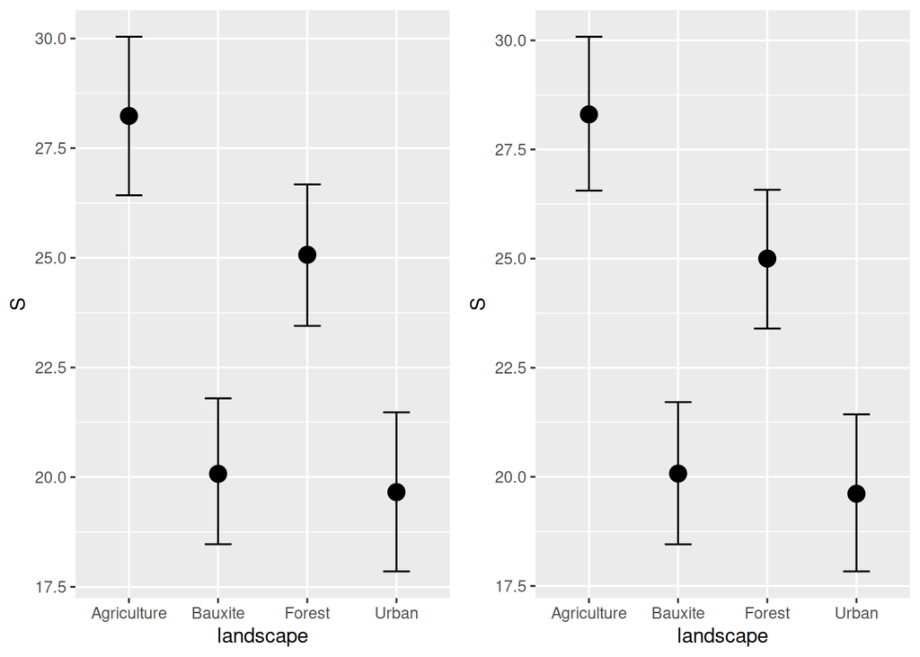

```r
p1 = plot(conditional_effects(fit.anova1.dummy), plot=FALSE)
p2 = plot(conditional_effects(fit.anova1.effect), plot=FALSE)
plot_grid(p1[[1]], p2[[1]])
```

While effect-coding (`~0+landscape`) gives group-level means in the summary (they are the parameters here), for dummy-coding (`~landscape`) we can use emmeans to get these predictions

```r
emmeans(fit.anova1.dummy, ~landscape)
```

```
 landscape   emmean lower.HPD upper.HPD
 Agriculture   28.2      26.4      30.0
 Bauxite       20.1      18.5      21.8
 Forest        25.1      23.5      26.7
 Urban         19.7      17.8      21.5

Point estimate displayed: median
HPD interval probability: 0.95
```

Also all their pairwise difference / contrasts

```r
pairs(emmeans(fit.anova1.dummy, ~landscape))
```

```
 contrast              estimate lower.HPD upper.HPD
 Agriculture - Bauxite    8.143     5.840     10.48
 Agriculture - Forest     3.168     0.791      5.59
 Agriculture - Urban      8.582     6.124     11.12
 Bauxite - Forest        -4.988    -7.225     -2.72
 Bauxite - Urban          0.432    -1.929      3.07
 Forest - Urban           5.411     3.004      7.89

Point estimate displayed: median
HPD interval probability: 0.95
```

For most pairwise comparisons, the mean difference is far away from 0 (CI does not cover 0). Is there an overall test to check if species richness changes with landscape (ANOVA)?

We test the model against an intercept-only model (LOO model comparison)

```r
fit.anova1.null = brm(S ~ 1, # brms already chooses intercept prior
                      data = birds)
```

```r
summary(fit.anova1.null)
```

```
 Family: gaussian
  Links: mu = identity; sigma = identity
Formula: S ~ 1
   Data: birds (Number of observations: 257)
  Draws: 4 chains, each with iter = 2000; warmup = 1000; thin = 1;
         total post-warmup draws = 4000

Regression Coefficients:
          Estimate Est.Error l-95% CI u-95% CI Rhat Bulk_ESS Tail_ESS
Intercept    23.28      0.48    22.32    24.19 1.00     3889     2783

Further Distributional Parameters:
      Estimate Est.Error l-95% CI u-95% CI Rhat Bulk_ESS Tail_ESS
sigma     7.83      0.34     7.19     8.53 1.00     3638     2496

Draws were sampled using sampling(NUTS). For each parameter, Bulk_ESS
and Tail_ESS are effective sample size measures, and Rhat is the potential
scale reduction factor on split chains (at convergence, Rhat = 1).
```

```r
LOO(fit.anova1.null, fit.anova1.dummy)
```

```
                 elpd_diff se_diff
fit.anova1.dummy   0.0       0.0
fit.anova1.null  -27.1       7.3
```

Yes, we see a strong support for the ~landscape model.

Finally, here’s a nicer plot for the fitted values vs data

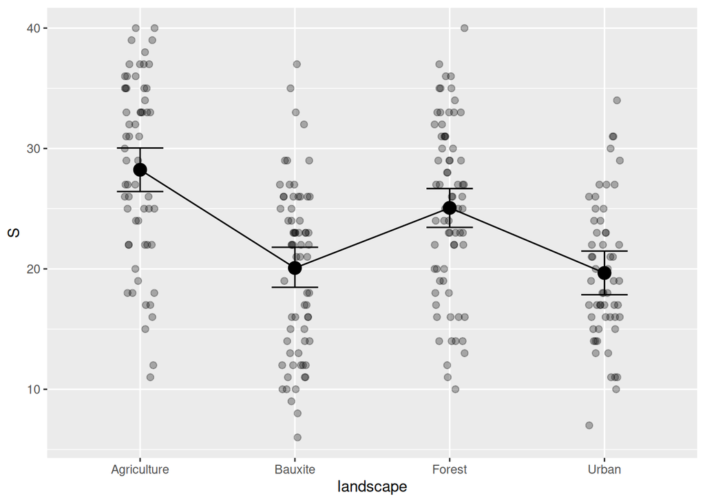

```r
p1 = plot(conditional_effects(fit.anova1.dummy,"landscape"),
          points=TRUE,
          point_args=list(width=0.1, alpha=0.3),
          plot = FALSE
)
p1[[1]] + geom_line(aes(group="landscape"))
```

# Two categorical predictors

We include a 2nd predictor “area”, here as a categorical with 2 levels (small/large).

**Question:** Surely, richness is higher in larger areas, but does the difference depend on landscape type?

–> We fit an additive and an interaction model (additive works with dummy-coding only)

```r
birds$area = cut(birds$log.area., 2, labels=c("small","large"))
head(birds)
```

```
  patch  S   landscape  area  log.area. year
1  ag1a 24 Agriculture small  0.5453297 2005
2  ag1b 15 Agriculture small -0.2107610 2005
3  ag1c 25 Agriculture small  0.3492867 2005
4  ag1d 35 Agriculture large  0.9180241 2005
5  ag2a 32 Agriculture small  0.1378772 2005
6  ag2b 40 Agriculture large  1.7729067 2005
```

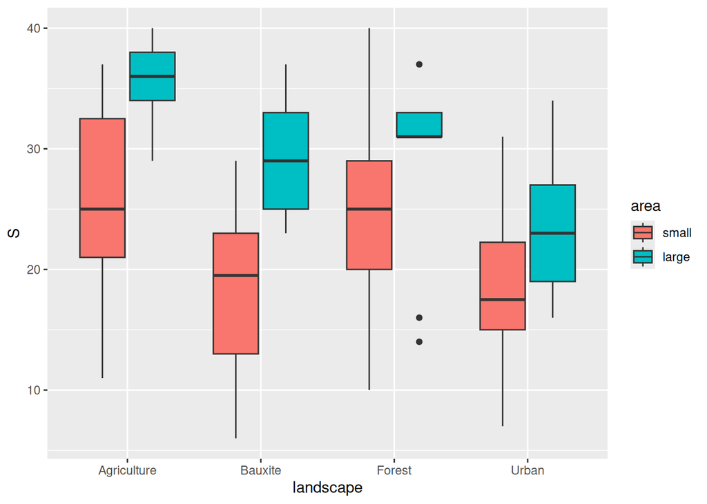

```r
ggplot(birds, aes(landscape, S)) +
  geom_boxplot(aes(fill=area))
```

## Additive model

```r
fit.anova2.add = brm(S ~ landscape+area,
                     prior = prior(normal(0,10), class=b),
                     data = birds)
```

With multiple categorical predictors (& their interaction), the estimated parameters in the summary table become less interpretable. Nevertheless, always look at the summary table to check Rhat values for convergence.

```r
summary(fit.anova2.add, prior=TRUE)
```

```
 Family: gaussian
  Links: mu = identity; sigma = identity
Formula: S ~ landscape + area
   Data: birds (Number of observations: 257)
  Draws: 4 chains, each with iter = 2000; warmup = 1000; thin = 1;
         total post-warmup draws = 4000

Priors:
b ~ normal(0, 10)
Intercept ~ student_t(3, 23, 8.9)
<lower=0> sigma ~ student_t(3, 0, 8.9)

Regression Coefficients:
                 Estimate Est.Error l-95% CI u-95% CI Rhat Bulk_ESS Tail_ESS
Intercept           26.08      0.86    24.42    27.81 1.00     3331     2941
landscapeBauxite    -7.00      1.11    -9.17    -4.81 1.00     3682     3168
landscapeForest     -2.00      1.11    -4.10     0.21 1.00     3324     3110
landscapeUrban      -7.63      1.15    -9.89    -5.44 1.00     3398     3040
arealarge            7.73      1.05     5.65     9.74 1.00     4909     2991

Further Distributional Parameters:
      Estimate Est.Error l-95% CI u-95% CI Rhat Bulk_ESS Tail_ESS
sigma     6.37      0.28     5.84     6.97 1.00     4727     2275

Draws were sampled using sampling(NUTS). For each parameter, Bulk_ESS
and Tail_ESS are effective sample size measures, and Rhat is the potential
scale reduction factor on split chains (at convergence, Rhat = 1).
```

Additive effects means parallel lines

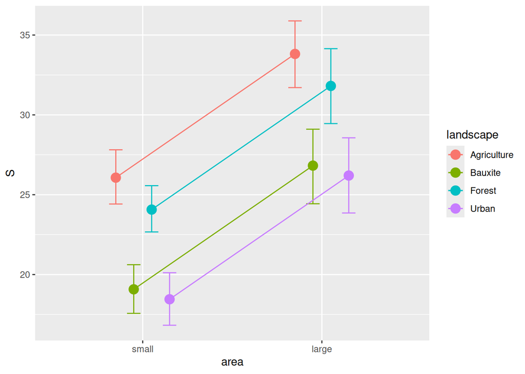

```r
p1 = plot(conditional_effects(fit.anova2.add, effects="area:landscape"),
          plot=FALSE)
p1[[1]] + geom_line(aes(group=landscape),
                    position=position_dodge(0.4))
```

Means and contrasts averaged over landscapes (i.e. landscape is averaged out, and means are displayed for `~area`)

```r
emmeans(fit.anova2.add, ~area)
```

```
 area  emmean lower.HPD upper.HPD
 small   21.9      21.1      22.7
 large   29.7      27.9      31.6

Results are averaged over the levels of: landscape
Point estimate displayed: median
HPD interval probability: 0.95
```

```r
emmeans(fit.anova2.add, ~area) |> pairs()
```

```
 contrast      estimate lower.HPD upper.HPD
 small - large    -7.75     -9.81     -5.74

Results are averaged over the levels of: landscape
Point estimate displayed: median
HPD interval probability: 0.95
```

Now the other way round! Again parallel lines because of additive effects.

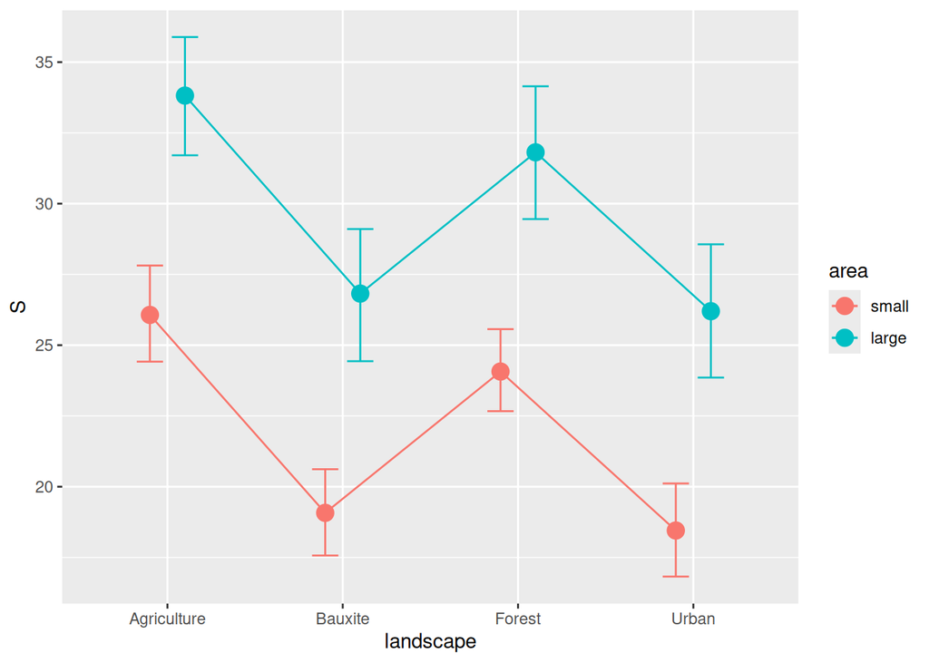

```r
p1 = plot(conditional_effects(fit.anova2.add, effects="landscape:area"),
          plot=FALSE)
p1[[1]] + geom_line(aes(group=area),
                    position=position_dodge(0.4))
```

Means and contrasts averaged over area (the same kind of predictions we did in the previous 1-way ANOVA `S~landscape`)

```r
emmeans(fit.anova2.add, ~landscape)
```

```
 landscape   emmean lower.HPD upper.HPD
 Agriculture   29.9      28.4      31.6
 Bauxite       22.9      21.3      24.6
 Forest        27.9      26.2      29.6
 Urban         22.3      20.5      24.0

Results are averaged over the levels of: area
Point estimate displayed: median
HPD interval probability: 0.95
```

```r
emmeans(fit.anova2.add, ~landscape) |> pairs()
```

```
 contrast              estimate lower.HPD upper.HPD
 Agriculture - Bauxite    7.006     4.772      9.10
 Agriculture - Forest     2.022    -0.225      4.08
 Agriculture - Urban      7.595     5.560     10.01
 Bauxite - Forest        -5.010    -7.236     -3.04
 Bauxite - Urban          0.607    -1.628      2.76
 Forest - Urban           5.615     3.425      7.76

Results are averaged over the levels of: area
Point estimate displayed: median
HPD interval probability: 0.95
```

## Interaction model

Full interaction model means individual means for all level-combinations, although it’s not immediately obvious from the summary table.

```r
fit.anova2.int = brm(S ~ landscape*area,
                     prior = prior(normal(0,10), class=b),
                     data = birds)
```

```r
summary(fit.anova2.int, prior=TRUE)
```

```
 Family: gaussian
  Links: mu = identity; sigma = identity
Formula: S ~ landscape * area
   Data: birds (Number of observations: 257)
  Draws: 4 chains, each with iter = 2000; warmup = 1000; thin = 1;
         total post-warmup draws = 4000

Priors:
b ~ normal(0, 10)
Intercept ~ student_t(3, 23, 8.9)
<lower=0> sigma ~ student_t(3, 0, 8.9)

Regression Coefficients:
                           Estimate Est.Error l-95% CI u-95% CI Rhat Bulk_ESS Tail_ESS
Intercept                     25.60      0.95    23.74    27.47 1.00     1883     2426
landscapeBauxite              -6.91      1.26    -9.35    -4.44 1.00     2277     2585
landscapeForest               -1.09      1.24    -3.54     1.29 1.00     2369     2873
landscapeUrban                -6.76      1.28    -9.27    -4.25 1.00     2458     2894
arealarge                      9.43      1.73     5.93    12.75 1.00     1863     2210
landscapeBauxite:arealarge     1.26      2.75    -4.28     6.74 1.00     2765     3276
landscapeForest:arealarge     -5.05      2.76   -10.48     0.43 1.00     2801     3115
landscapeUrban:arealarge      -4.18      2.79    -9.58     1.46 1.00     2739     2958

Further Distributional Parameters:
      Estimate Est.Error l-95% CI u-95% CI Rhat Bulk_ESS Tail_ESS
sigma     6.31      0.28     5.80     6.89 1.00     4680     2607

Draws were sampled using sampling(NUTS). For each parameter, Bulk_ESS
and Tail_ESS are effective sample size measures, and Rhat is the potential
scale reduction factor on split chains (at convergence, Rhat = 1).
```

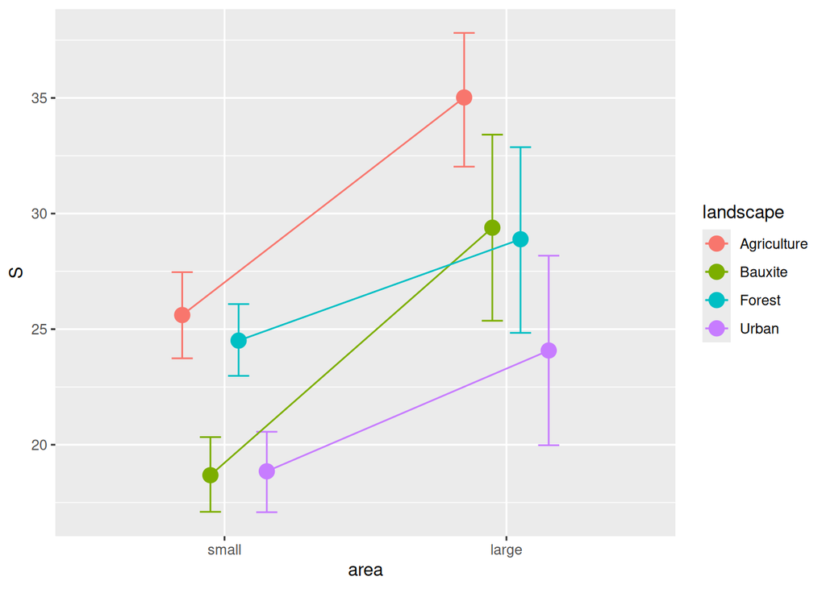

```r
p1 = plot(conditional_effects(fit.anova2.int, effects="area:landscape"),
          plot=FALSE)
p1[[1]] + geom_line(aes(group=landscape),
                    position=position_dodge(0.4))
```

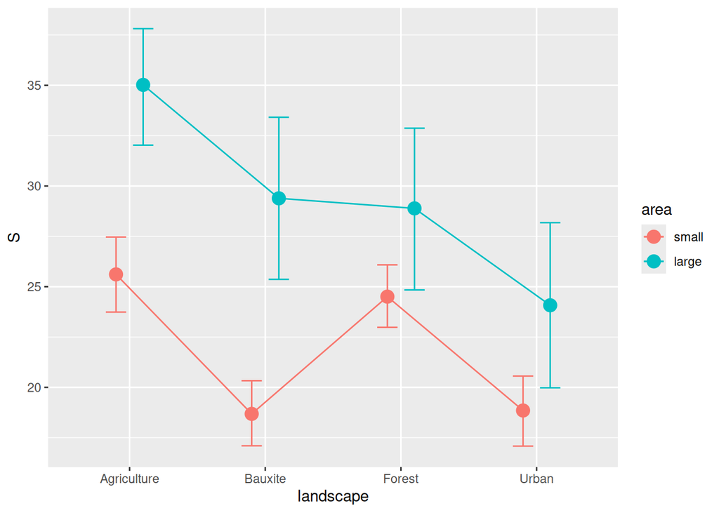

```r
p1 = plot(conditional_effects(fit.anova2.int, effects="landscape:area"),
          plot=FALSE)
p1[[1]] + geom_line(aes(group=area),
                    position=position_dodge(0.4))
```

Careful when averaging over a prediction in interaction models

```r
emmeans(fit.anova2.int, ~area)
```

```
NOTE: Results may be misleading due to involvement in interactions
```

```
 area  emmean lower.HPD upper.HPD
 small   21.9      21.1      22.8
 large   29.3      27.4      31.3

Results are averaged over the levels of: landscape
Point estimate displayed: median
HPD interval probability: 0.95
```

```r
emmeans(fit.anova2.int, ~area) |> pairs()
```

```
NOTE: Results may be misleading due to involvement in interactions
```

```
 contrast      estimate lower.HPD upper.HPD
 small - large    -7.45     -9.53     -5.28

Results are averaged over the levels of: landscape
Point estimate displayed: median
HPD interval probability: 0.95
```

Since the summary table doesn’t give us the predicted means right away, we can calculate them

```r
emmeans(fit.anova2.int, ~area:landscape)
```

```
 area  landscape   emmean lower.HPD upper.HPD
 small Agriculture   25.6      23.8      27.5
 large Agriculture   35.0      32.3      38.1
 small Bauxite       18.7      17.1      20.3
 large Bauxite       29.4      25.5      33.5
 small Forest        24.5      23.0      26.1
 large Forest        28.9      24.8      32.7
 small Urban         18.9      17.1      20.6
 large Urban         24.1      20.1      28.3

Point estimate displayed: median
HPD interval probability: 0.95
```

Now back to our research question, if the area effect on species richness changes with landscape type.

```r
LOO(fit.anova2.int, fit.anova2.add)
```

```
               elpd_diff se_diff
fit.anova2.int  0.0       0.0
fit.anova2.add -0.7       2.3
```

No, the data does not support the hypothesis and we conclude that the area effect is independent of landscape type here. There is just a small difference in elpd (in favor of the interaction), but compared to the associated standard error we have to treat both models as equally performing. The principle of parsimony dictates to prefer the less complex model, here the additive one.

# Categorical and continuous predictors

Now we use the full resolution of area as continuous predictor.

**Same question:** Does the area-effect change between landscape types?  
–> We test additive vs interaction ANCOVA

If chosen as an exercise, you can leave out the priors for now and focus on correct model definition.

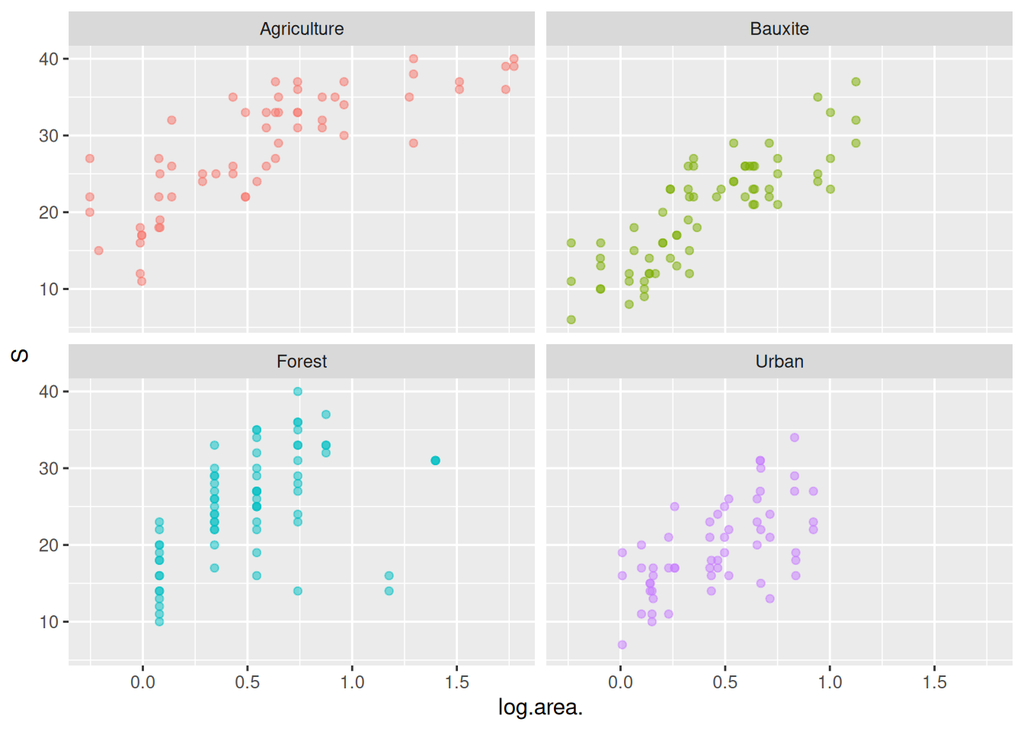

```r
ggplot(birds, aes(x=log.area., y=S, col=landscape)) +
  geom_point(alpha=0.5)  +
  facet_wrap(~landscape) +
  theme(legend.position="none")
```

## Additive model

First, we check which priors to assign.

In the additive model, we need priors for discrete landscape effects (intercept effects) and for area (slope).  
–> We use overall prior for all effects (`class=b`) and override this only for area slope (`class=b, coef=log.area.`)

```r
default_prior(S ~ landscape+log.area., data=birds)
```

```
                 prior     class             coef group resp dpar nlpar lb ub       source
                (flat)         b                                                   default
                (flat)         b landscapeBauxite                             (vectorized)
                (flat)         b  landscapeForest                             (vectorized)
                (flat)         b   landscapeUrban                             (vectorized)
                (flat)         b        log.area.                             (vectorized)
 student_t(3, 23, 8.9) Intercept                                                   default
  student_t(3, 0, 8.9)     sigma                                         0         default
```

```r
fit.ancova.add = brm(S ~ landscape+log.area.,
                     prior =
                       prior(normal(0,10), class=b) +
                       prior(normal(10,10), class=b, coef=log.area.),
                     data = birds)
```

```r
summary(fit.ancova.add)
```

```
 Family: gaussian
  Links: mu = identity; sigma = identity
Formula: S ~ landscape + log.area.
   Data: birds (Number of observations: 257)
  Draws: 4 chains, each with iter = 2000; warmup = 1000; thin = 1;
         total post-warmup draws = 4000

Regression Coefficients:
                 Estimate Est.Error l-95% CI u-95% CI Rhat Bulk_ESS Tail_ESS
Intercept           20.90      0.80    19.31    22.45 1.00     3208     2893
landscapeBauxite    -5.97      0.87    -7.66    -4.20 1.00     3451     3091
landscapeForest     -2.27      0.88    -3.98    -0.53 1.00     3679     2941
landscapeUrban      -7.05      0.92    -8.82    -5.25 1.00     3864     3108
log.area.           12.69      0.83    11.09    14.35 1.00     4651     2589

Further Distributional Parameters:
      Estimate Est.Error l-95% CI u-95% CI Rhat Bulk_ESS Tail_ESS
sigma     4.98      0.23     4.55     5.44 1.00     4695     2665

Draws were sampled using sampling(NUTS). For each parameter, Bulk_ESS
and Tail_ESS are effective sample size measures, and Rhat is the potential
scale reduction factor on split chains (at convergence, Rhat = 1).
```

In the additive model, each landscape type has its own intercept, but a joint slope with area.

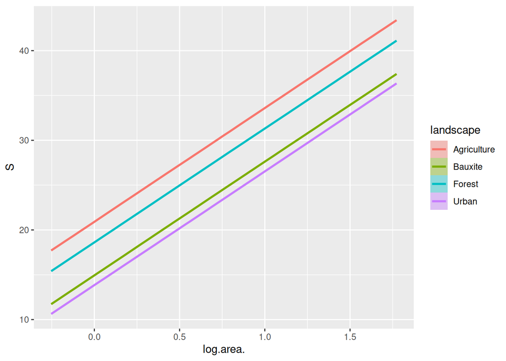

```r
plot(conditional_effects(fit.ancova.add, effects="log.area.:landscape", prob=0))
```

We can do some ggplot2 magic to plot seperately for each landscape type

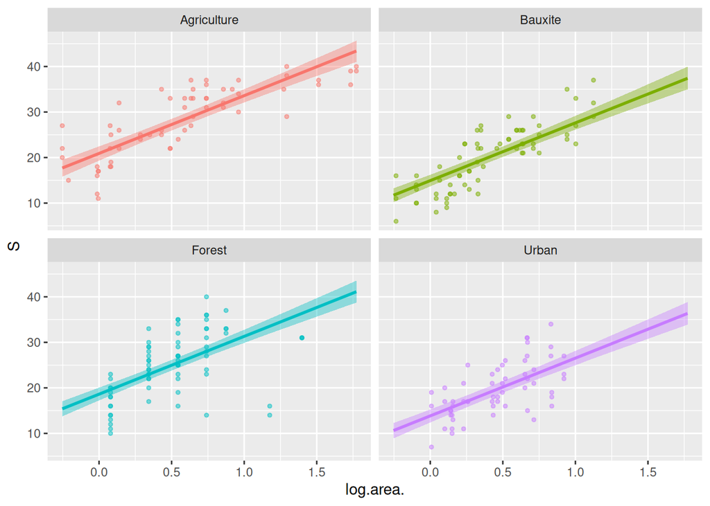

```r
p1 = plot(conditional_effects(fit.ancova.add, effects="log.area.:landscape"),
          points=T,
          point_args=c(size=1.0, alpha=0.5),
          plot=F)
p1[[1]] +
  facet_wrap(~landscape) +
  theme(legend.position="none")
```

We can compute intercepts (at mean area) & contrasts with emmeans

```r
emmeans(fit.ancova.add, ~landscape)
```

```
 landscape   emmean lower.HPD upper.HPD
 Agriculture   27.1      25.8      28.4
 Bauxite       21.1      20.0      22.3
 Forest        24.8      23.6      26.0
 Urban         20.0      18.8      21.3

Point estimate displayed: median
HPD interval probability: 0.95
```

```r
emmeans(fit.ancova.add, ~landscape) |> pairs()
```

```
 contrast              estimate lower.HPD upper.HPD
 Agriculture - Bauxite     5.97     4.170      7.61
 Agriculture - Forest      2.29     0.559      4.00
 Agriculture - Urban       7.06     5.262      8.82
 Bauxite - Forest         -3.69    -5.335     -2.06
 Bauxite - Urban           1.07    -0.574      2.86
 Forest - Urban            4.77     3.067      6.49

Point estimate displayed: median
HPD interval probability: 0.95
```

## Interaction model

Again, we check which priors to assign.

Here, we need priors for all landscape effects (intercept effects), slope in reference level, and changes in slopes  
–> I could not find a good way to shorten this, assign priors manually

```r
default_prior(S ~ landscape*log.area., data=birds)
```

```
                 prior     class                       coef group resp dpar nlpar lb ub       source
                (flat)         b                                                             default
                (flat)         b           landscapeBauxite                             (vectorized)
                (flat)         b landscapeBauxite:log.area.                             (vectorized)
                (flat)         b            landscapeForest                             (vectorized)
                (flat)         b  landscapeForest:log.area.                             (vectorized)
                (flat)         b             landscapeUrban                             (vectorized)
                (flat)         b   landscapeUrban:log.area.                             (vectorized)
                (flat)         b                  log.area.                             (vectorized)
 student_t(3, 23, 8.9) Intercept                                                             default
  student_t(3, 0, 8.9)     sigma                                                   0         default
```

```r
fit.ancova.int = brm(S ~ landscape*log.area.,
                     prior =
                       prior(normal(0,10), class=b, coef=landscapeBauxite) +
                       prior(normal(0,10), class=b, coef=landscapeForest) +
                       prior(normal(0,10), class=b, coef=landscapeUrban) +
                       prior(normal(10,10), class=b, coef=log.area.) +
                       prior(normal(0,5), class=b, coef=landscapeBauxite:log.area.) +
                       prior(normal(0,5), class=b, coef=landscapeForest:log.area.) +
                       prior(normal(0,5), class=b, coef=landscapeUrban:log.area.),
                     data = birds)
```

```r
summary(fit.ancova.int)
```

```
 Family: gaussian
  Links: mu = identity; sigma = identity
Formula: S ~ landscape * log.area.
   Data: birds (Number of observations: 257)
  Draws: 4 chains, each with iter = 2000; warmup = 1000; thin = 1;
         total post-warmup draws = 4000

Regression Coefficients:
                           Estimate Est.Error l-95% CI u-95% CI Rhat Bulk_ESS Tail_ESS
Intercept                     21.41      0.92    19.66    23.27 1.00     2482     2642
landscapeBauxite              -7.79      1.25   -10.21    -5.41 1.00     2655     2936
landscapeForest               -2.00      1.35    -4.64     0.66 1.00     2511     2626
landscapeUrban                -7.59      1.50   -10.51    -4.63 1.00     2243     2435
log.area.                     11.78      1.11     9.66    13.98 1.00     2325     2639
landscapeBauxite:log.area.     4.15      1.88     0.54     7.83 1.00     2615     2678
landscapeForest:log.area.     -0.63      1.94    -4.37     3.26 1.00     2791     2916
landscapeUrban:log.area.       1.03      2.40    -3.70     5.67 1.00     2777     2472

Further Distributional Parameters:
      Estimate Est.Error l-95% CI u-95% CI Rhat Bulk_ESS Tail_ESS
sigma     4.93      0.23     4.50     5.39 1.00     4487     2715

Draws were sampled using sampling(NUTS). For each parameter, Bulk_ESS
and Tail_ESS are effective sample size measures, and Rhat is the potential
scale reduction factor on split chains (at convergence, Rhat = 1).
```

In the interaction model, each landscape type has its own intercept & own slope.

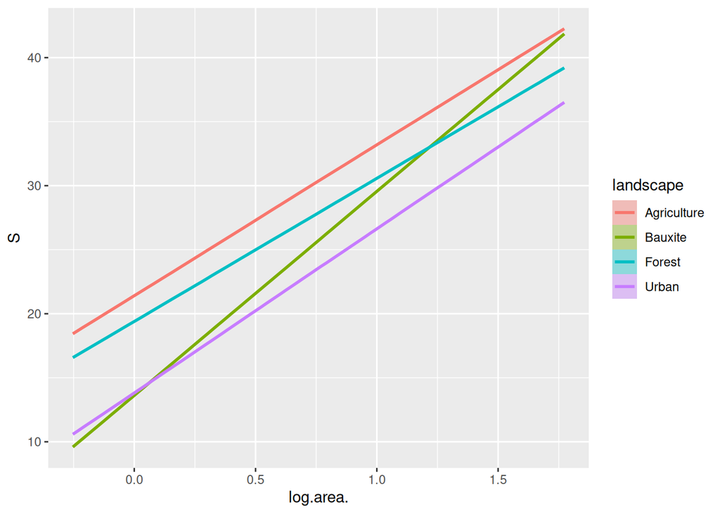

```r
plot(conditional_effects(fit.ancova.int, effects="log.area.:landscape", prob=0))
```

We can do some ggplot2 magic to plot seperately for each landscape type

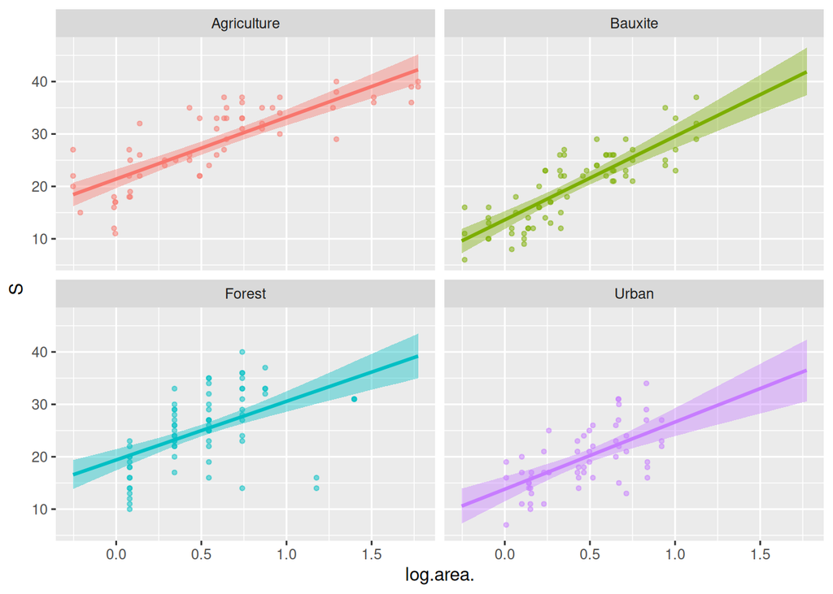

```r
p1 = plot(conditional_effects(fit.ancova.int, effects="log.area.:landscape"),
          points=T,
          point_args=c(size=1.0, alpha=0.5),
          plot=F)
p1[[1]] +
  facet_wrap(~landscape) +
  theme(legend.position="none")
```

Here we can compute slopes and their contrasts with a new function `emtrends()`. `var=` specifies the continuous predictor, for which slopes are presented.

```r
emtrends(fit.ancova.int, ~landscape, var="log.area.")
```

```
 landscape   log.area..trend lower.HPD upper.HPD
 Agriculture            11.8      9.65      14.0
 Bauxite                15.9     12.65      18.9
 Forest                 11.2      7.92      14.4
 Urban                  12.8      8.52      17.2

Point estimate displayed: median
HPD interval probability: 0.95
```

```r
emtrends(fit.ancova.int, ~landscape, var="log.area.") |> pairs()
```

```
 contrast              estimate lower.HPD upper.HPD
 Agriculture - Bauxite   -4.171    -7.911    -0.622
 Agriculture - Forest     0.617    -3.094     4.449
 Agriculture - Urban     -1.072    -5.721     3.658
 Bauxite - Forest         4.743     0.359     9.244
 Bauxite - Urban          3.124    -1.853     8.500
 Forest - Urban          -1.635    -6.907     4.108

Point estimate displayed: median
HPD interval probability: 0.95
```

Now back to our research question, if the area effect (slopes) on species richness changes with landscape type.

```r
LOO(fit.ancova.add, fit.ancova.int)
```

```
               elpd_diff se_diff
fit.ancova.int  0.0       0.0
fit.ancova.add -0.7       2.0
```

Again, no strong support for the interaction model. Area-effect does not vary strongly between landscape types (same result as the 2-way ANOVA).

**For the sake of brevity I left out convergence checks and posterior predictive checks, but you should always include them in any analysis**

```r
plot(fit)
pp_check(fit, ndraws=100)
pp_check(fit, type="scatter_avg")
check_model(fit, check=c("linearity","homogeneity","qq","normality"))
```

# Exercise

Now that we have covered the most important aspects of linear models, apply this to a dataset of your choice. Maybe you have a dataset and some hypotheses to test in your own research project. Otherwise, the `palmerpenguins` package has a nice dataset to fit some linear models:

allisonhorst.github.io/palmerpenguins/index.html

```r
library("palmerpenguins")
str(penguins)
```

```
tibble [344 × 8] (S3: tbl_df/tbl/data.frame)
 $ species          : Factor w/ 3 levels "Adelie","Chinstrap",..: 1 1 1 1 1 1 1 1 1 1 ...
 $ island           : Factor w/ 3 levels "Biscoe","Dream",..: 3 3 3 3 3 3 3 3 3 3 ...
 $ bill_length_mm   : num [1:344] 39.1 39.5 40.3 NA 36.7 39.3 38.9 39.2 34.1 42 ...
 $ bill_depth_mm    : num [1:344] 18.7 17.4 18 NA 19.3 20.6 17.8 19.6 18.1 20.2 ...
 $ flipper_length_mm: int [1:344] 181 186 195 NA 193 190 181 195 193 190 ...
 $ body_mass_g      : int [1:344] 3750 3800 3250 NA 3450 3650 3625 4675 3475 4250 ...
 $ sex              : Factor w/ 2 levels "female","male": 2 1 1 NA 1 2 1 2 NA NA ...
 $ year             : int [1:344] 2007 2007 2007 2007 2007 2007 2007 2007 2007 2007 ...
```